# Correlation between satisficing items and maximizing, well-being, personality, and self-rumination

Gabriel Baník, Lenka Vargová

8/15/2020

Correlation of satisficing items and other examined variables (as was suggested in the review)

As well as maximizing, satisficing might also should be measured as a two-component model (as a goal and as a strategy). It seems that items (" If I am happy with my work, I do not seek better opportunities" [DMTI_las_1]) and (" I do not ask for more than what satisfies me" [DMTI_las_3]) are more related to “satisficing as a goal”, whereas items (“In choosing between alternatives, I stop at the first that works for me” [DMTI_las_2]) and (“When I watch TV or listen to the radio, I tend to follow the first program that I find interesting” [DMTI_las_4]) are more related to “satisficing as a strategy”. We inspect how items from satisficing are related to examined variables in the current study (see supplementary materials) and we found that item (" If I am happy with my work, I do not seek better opportunities" [DMTI_las_1]) was in a positive relationship with maximizing as a strategy, item (“In choosing between alternatives, I stop at the first that works for me” [DMTI_las_2]) was in a negative relationship with maximizing as a strategy, and item (" I do not ask for more than what satisfies me" [DMTI_las_3]) was in a negative relationship with maximizing as a goal. Different relationship of satisficing items and maximizing as a goal a and maximizing as strategy can point to suggestion to measure also satisficing as two-component model. On the other hand satisficing items were unrelated to every other examined variables which can appear to question the extent to which satisficing is a valid construct (in the sense of, for example, its criterion validity).

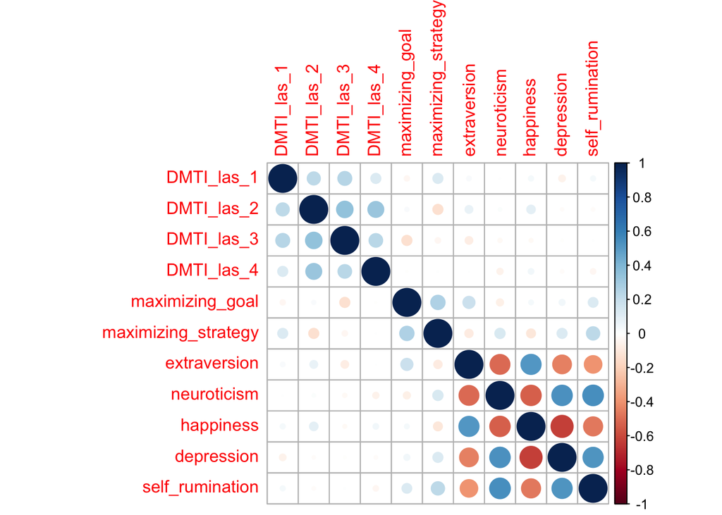

```
##               variable1           variable2             r        rse
## 1            DMTI_las_1          DMTI_las_2  0.2192520607 0.04212398
## 2            DMTI_las_1          DMTI_las_3  0.2485945057 0.04152270
## 3            DMTI_las_1          DMTI_las_4  0.1297954605 0.04348661
## 4            DMTI_las_1     maximizing_goal -0.0392377130 0.04429566
## 5            DMTI_las_1 maximizing_strategy  0.1275612458 0.04352996
## 6            DMTI_las_1        extraversion  0.0283253549 0.04421389
## 7            DMTI_las_1         neuroticism  0.0019499698 0.04425428
## 8            DMTI_las_1           happiness  0.0341009160 0.04419157
## 9            DMTI_las_1          depression -0.0583106977 0.04409952
## 10           DMTI_las_1     self_rumination  0.0325088565 0.04424013
## 11           DMTI_las_2          DMTI_las_3  0.3469484538 0.03897604
## 12           DMTI_las_2          DMTI_las_4  0.3228638642 0.03961324
## 13           DMTI_las_2     maximizing_goal  0.0237462144 0.04422012
## 14           DMTI_las_2 maximizing_strategy -0.1298512191 0.04350034
```

[output cut: 318 more lines]